# **MATH 3190 Homework 6**

Due March 19, 2026  
Focus: Notes 7 Part 2  
Total Points: 90 + 10 (Self-Critique Comment and Uploading to GitHub) = 100

Note that your homework should be completed in Quarto. You can just add your answers and code to this document in the appropriate part. The file should be rendered as an html document or pdf document (html is quicker to render and you will need an installation of LaTeX to render as a pdf). You will “turn in” this homework by uploading the files, the .qmd and output file, to your GitHub `Math_3190_Assignment` repository in the `Homework/Homework_6` directory. Make sure all supporting files (if there are any) are in this directory as well. You should use `git` and `Unix` commands in a terminal for this (i.e. don’t manually upload files to GitHub). In addition, you will submit just your html or pdf file on Canvas to unlock the solutions.

Don’t forget to also put a self-critique comment on Canvas indicating what you did correctly and incorrectly and include any questions you may have about the assignment after submitting the assignment and thoroughly looking through the solutions.

# Problem 1 (28 points)

An automobile consulting company wants to understand the factors on which the pricing of cars depends. The dataset `car_price_prediction` in the `math3190package` (and also found in the GitHub data folder) has information on the sales of 4340 vehicles.

### Part a (3 points)

Create new variables in the dataset by taking the natural log of selling price, year, and km_driven. This will help linearize the association between variables. Then fit a linear model for predicting the log of selling price using all other variables except “name”, “year”, “selling_price”, and “km_driven” (the logged variables should be used instead of those last three). Also, there is only one vehicle with a fuel type of “Electric”. Remove that vehicle from the dataset.

```r
library(math3190package) |> suppressPackageStartupMessages()
car_price_prediction <- car_price_prediction |> rename(car_year = year)

car_price_pred_log <- car_price_prediction |>
  mutate(logselling_price = log(selling_price)) |>
  mutate(logyear = log(car_year)) |>
  mutate(logkm_driven = log(km_driven)) |>
  filter(fuel != 'Electric')

carp_model <- lm(logselling_price ~ . -name - car_year - km_driven - selling_price,
                 data = car_price_pred_log)
summary(carp_model)
```

```
Call:
lm(formula = logselling_price ~ . - name - car_year - km_driven -
    selling_price, data = car_price_pred_log)

Residuals:
     Min       1Q   Median       3Q      Max
-1.81328 -0.30396  0.00055  0.28820  2.32756

Coefficients:
                              Estimate Std. Error t value Pr(>|t|)
(Intercept)                 -1.686e+03  3.345e+01 -50.406  < 2e-16 ***
fuelDiesel                   5.842e-01  7.526e-02   7.763 1.03e-14 ***
fuelLPG                     -5.132e-02  1.233e-01  -0.416 0.677337
fuelPetrol                   6.553e-02  7.539e-02   0.869 0.384754
seller_typeIndividual       -1.555e-01  1.817e-02  -8.555  < 2e-16 ***
seller_typeTrustmark Dealer  3.089e-01  4.910e-02   6.292 3.45e-10 ***
transmissionManual          -8.001e-01  2.432e-02 -32.897  < 2e-16 ***
ownerFourth & Above Owner   -1.418e-01  5.502e-02  -2.577 0.010003 *
ownerSecond Owner           -4.521e-02  1.840e-02  -2.458 0.014024 *
ownerTest Drive Car          7.418e-02  1.192e-01   0.622 0.533702
ownerThird Owner            -1.156e-01  3.058e-02  -3.780 0.000159 ***
logyear                      2.234e+02  4.389e+00  50.896  < 2e-16 ***
logkm_driven                -3.601e-02  1.010e-02  -3.566 0.000366 ***
---
Signif. codes:  0 '***' 0.001 '**' 0.01 '*' 0.05 '.' 0.1 ' ' 1

Residual standard error: 0.4705 on 4326 degrees of freedom
Multiple R-squared:  0.6866,    Adjusted R-squared:  0.6858
F-statistic: 789.9 on 12 and 4326 DF,  p-value: < 2.2e-16
```

### Part b (5 points)

Now fit some LASSO models for predicting log selling price using all but the “name” variable. Try the following values for the regularization parameter: $\lambda=0,\ 0.01,\ 0.1,$ and $1$ and comment on how the coefficients of the model change.

Note: when $\lambda=0$, the LASSO coefficients should equal the OLS model coefficients. However, they will actually be a bit off here. That is because the `glmnet()` function has a `thresh` argument that sets a threshold for convergence. It is, by default, set to `1e-07`. To make the parameters match, you can change that to `thresh = 1e-14` instead. This is not necessary, though.

```r
library(glmnet) |> suppressPackageStartupMessages()
library(glmnetUtils) |> suppressPackageStartupMessages()

price_lasso <- glmnet(logselling_price ~ . -name, data = car_price_pred_log,
                      alpha = 1)
coef(price_lasso, s = 0)
```

```
20 x 1 sparse Matrix of class "dgCMatrix"
                                      s=0
(Intercept)                 -1.824324e+02
car_year                     8.544395e-02
selling_price                7.255059e-07
km_driven                    2.342955e-07
fuelCNG                     -6.119756e-02
fuelDiesel                   2.996933e-01
fuelLPG                     -1.399522e-01
fuelPetrol                   .
seller_typeDealer            .
seller_typeIndividual       -1.075524e-01
seller_typeTrustmark Dealer  1.781800e-01
transmissionAutomatic        1.666474e-01
transmissionManual          -1.098192e-12
ownerFirst Owner             1.474065e-02
ownerFourth & Above Owner   -1.124192e-01
ownerSecond Owner            .
ownerTest Drive Car          3.284238e-02
ownerThird Owner            -6.537175e-02
logyear                      2.986201e+00
logkm_driven                 .
```

```r
coef(price_lasso, s = 0.01)
```

```
20 x 1 sparse Matrix of class "dgCMatrix"
                                   s=0.01
(Intercept)                 -1.775575e+02
car_year                     8.425654e-02
selling_price                7.266744e-07
km_driven                    .
fuelCNG                      .
fuelDiesel                   2.932229e-01
fuelLPG                     -3.278518e-02
fuelPetrol                   .
seller_typeDealer            .
seller_typeIndividual       -9.982522e-02
seller_typeTrustmark Dealer  1.329586e-01
transmissionAutomatic        1.435525e-01
transmissionManual          -5.804635e-13
ownerFirst Owner             8.905659e-03
ownerFourth & Above Owner   -5.929175e-02
ownerSecond Owner            .
ownerTest Drive Car          .
ownerThird Owner            -3.598738e-02
logyear                      2.661651e+00
logkm_driven                 .
```

```r
coef(price_lasso, s = 0.1)
```

```
20 x 1 sparse Matrix of class "dgCMatrix"
                                    s=0.1
(Intercept)                 -1.458915e+02
car_year                     7.124996e-02
selling_price                7.156758e-07
km_driven                    .
fuelCNG                      .
fuelDiesel                   1.380019e-01
fuelLPG                      .
fuelPetrol                   .
seller_typeDealer            .
seller_typeIndividual        .
seller_typeTrustmark Dealer  .
transmissionAutomatic        .
transmissionManual           .
ownerFirst Owner             .
ownerFourth & Above Owner    .
ownerSecond Owner            .
ownerTest Drive Car          .
ownerThird Owner             .
logyear                      1.944628e+00
logkm_driven                 .
```

```r
coef(price_lasso, s = 1)
```

```
20 x 1 sparse Matrix of class "dgCMatrix"
                                 s=1
(Intercept)                 12.76421
car_year                     .
selling_price                .
km_driven                    .
fuelCNG                      .
fuelDiesel                   .
fuelLPG                      .
fuelPetrol                   .
seller_typeDealer            .
seller_typeIndividual        .
seller_typeTrustmark Dealer  .
transmissionAutomatic        .
transmissionManual           .
ownerFirst Owner             .
ownerFourth & Above Owner    .
ownerSecond Owner            .
ownerTest Drive Car          .
ownerThird Owner             .
logyear                      .
logkm_driven                 .
```

### Part c (4 points)

Now fit some ridge regression models for predicting log selling price using all but name. Try the following values for the regularization parameter: $\lambda=0,\ 0.01,\ 0.1,$ and $1$ and comment on how the coefficients of the model change.

```r
price_ridge <- glmnet(logselling_price ~ . -name, data = car_price_pred_log,
                      alpha = 0, )
coef(price_ridge, s = 0)
```

```
20 x 1 sparse Matrix of class "dgCMatrix"
                                      s=0
(Intercept)                 -7.190987e+02
car_year                     4.272990e-02
selling_price                6.516313e-07
km_driven                    2.349048e-07
fuelCNG                     -2.095711e-01
fuelDiesel                   1.658448e-01
fuelLPG                     -2.953432e-01
fuelPetrol                  -1.532796e-01
seller_typeDealer            4.267947e-02
seller_typeIndividual       -6.806338e-02
seller_typeTrustmark Dealer  2.312074e-01
transmissionAutomatic        1.135744e-01
transmissionManual          -1.181859e-01
ownerFirst Owner             2.998936e-02
ownerFourth & Above Owner   -1.268913e-01
ownerSecond Owner           -1.520773e-03
ownerTest Drive Car          6.943824e-02
ownerThird Owner            -7.234879e-02
logyear                      8.488229e+01
logkm_driven                -1.127021e-02
```

```r
coef(price_ridge, s = 0.01)
```

```
20 x 1 sparse Matrix of class "dgCMatrix"
                                   s=0.01
(Intercept)                 -7.190987e+02
car_year                     4.272990e-02
selling_price                6.516313e-07
km_driven                    2.349048e-07
fuelCNG                     -2.095711e-01
fuelDiesel                   1.658448e-01
fuelLPG                     -2.953432e-01
fuelPetrol                  -1.532796e-01
seller_typeDealer            4.267947e-02
seller_typeIndividual       -6.806338e-02
seller_typeTrustmark Dealer  2.312074e-01
transmissionAutomatic        1.135744e-01
transmissionManual          -1.181859e-01
ownerFirst Owner             2.998936e-02
ownerFourth & Above Owner   -1.268913e-01
ownerSecond Owner           -1.520773e-03
ownerTest Drive Car          6.943824e-02
ownerThird Owner            -7.234879e-02
logyear                      8.488229e+01
logkm_driven                -1.127021e-02
```

```r
coef(price_ridge, s = 0.1)
```

```
20 x 1 sparse Matrix of class "dgCMatrix"
                                    s=0.1
(Intercept)                 -7.098133e+02
car_year                     4.212021e-02
selling_price                6.211046e-07
km_driven                    1.765368e-07
fuelCNG                     -2.043907e-01
fuelDiesel                   1.690446e-01
fuelLPG                     -2.907374e-01
fuelPetrol                  -1.563471e-01
seller_typeDealer            4.323102e-02
seller_typeIndividual       -6.853674e-02
seller_typeTrustmark Dealer  2.310854e-01
transmissionAutomatic        1.259126e-01
transmissionManual          -1.292672e-01
ownerFirst Owner             3.371156e-02
ownerFourth & Above Owner   -1.309278e-01
ownerSecond Owner           -4.470111e-03
ownerTest Drive Car          7.655900e-02
ownerThird Owner            -7.503448e-02
logyear                      8.383009e+01
logkm_driven                -1.376832e-02
```

```r
coef(price_ridge, s = 1)
```

```
20 x 1 sparse Matrix of class "dgCMatrix"
                                      s=1
(Intercept)                 -5.160803e+02
car_year                     3.056245e-02
selling_price                3.248329e-07
km_driven                   -3.377743e-07
fuelCNG                     -1.220867e-01
fuelDiesel                   1.550274e-01
fuelLPG                     -2.035899e-01
fuelPetrol                  -1.463295e-01
seller_typeDealer            5.196203e-02
seller_typeIndividual       -7.057402e-02
seller_typeTrustmark Dealer  1.805965e-01
transmissionAutomatic        1.854620e-01
transmissionManual          -1.854695e-01
ownerFirst Owner             6.731832e-02
ownerFourth & Above Owner   -1.511854e-01
ownerSecond Owner           -3.704557e-02
ownerTest Drive Car          1.258881e-01
ownerThird Owner            -9.142708e-02
logyear                      6.147617e+01
logkm_driven                -3.165036e-02
```

For lambda = 0 and 0.01 the coefficients are very similar, and 0.1 is also fairly similar. At 1 there is a big change in most of the variables.

### Part d (4 points)

Now fit some elastic net regression models for predicting log price using all but name. Try the following values for the regularization parameter: $\lambda=0,\ 0.01,\ 0.1,$ and $1$ for $\alpha=1/3$ and then comment on how the coefficients of the model change for each $\alpha$ from parts (b), (c), and (d).

```r
price_elastic <- glmnet(logselling_price ~ . -name, data = car_price_pred_log,
                      alpha = 1/3)
coef(price_ridge, s = 0)
```

```
20 x 1 sparse Matrix of class "dgCMatrix"
                                      s=0
(Intercept)                 -7.190987e+02
car_year                     4.272990e-02
selling_price                6.516313e-07
km_driven                    2.349048e-07
fuelCNG                     -2.095711e-01
fuelDiesel                   1.658448e-01
fuelLPG                     -2.953432e-01
fuelPetrol                  -1.532796e-01
seller_typeDealer            4.267947e-02
seller_typeIndividual       -6.806338e-02
seller_typeTrustmark Dealer  2.312074e-01
transmissionAutomatic        1.135744e-01
transmissionManual          -1.181859e-01
ownerFirst Owner             2.998936e-02
ownerFourth & Above Owner   -1.268913e-01
ownerSecond Owner           -1.520773e-03
ownerTest Drive Car          6.943824e-02
ownerThird Owner            -7.234879e-02
logyear                      8.488229e+01
logkm_driven                -1.127021e-02
```

```r
coef(price_ridge, s = 0.01)
```

```
20 x 1 sparse Matrix of class "dgCMatrix"
                                   s=0.01
(Intercept)                 -7.190987e+02
car_year                     4.272990e-02
selling_price                6.516313e-07
km_driven                    2.349048e-07
fuelCNG                     -2.095711e-01
fuelDiesel                   1.658448e-01
fuelLPG                     -2.953432e-01
fuelPetrol                  -1.532796e-01
seller_typeDealer            4.267947e-02
seller_typeIndividual       -6.806338e-02
seller_typeTrustmark Dealer  2.312074e-01
transmissionAutomatic        1.135744e-01
transmissionManual          -1.181859e-01
ownerFirst Owner             2.998936e-02
ownerFourth & Above Owner   -1.268913e-01
ownerSecond Owner           -1.520773e-03
ownerTest Drive Car          6.943824e-02
ownerThird Owner            -7.234879e-02
logyear                      8.488229e+01
logkm_driven                -1.127021e-02
```

```r
coef(price_ridge, s = 0.1)
```

```
20 x 1 sparse Matrix of class "dgCMatrix"
                                    s=0.1
(Intercept)                 -7.098133e+02
car_year                     4.212021e-02
selling_price                6.211046e-07
km_driven                    1.765368e-07
fuelCNG                     -2.043907e-01
fuelDiesel                   1.690446e-01
fuelLPG                     -2.907374e-01
fuelPetrol                  -1.563471e-01
seller_typeDealer            4.323102e-02
seller_typeIndividual       -6.853674e-02
seller_typeTrustmark Dealer  2.310854e-01
transmissionAutomatic        1.259126e-01
transmissionManual          -1.292672e-01
ownerFirst Owner             3.371156e-02
ownerFourth & Above Owner   -1.309278e-01
ownerSecond Owner           -4.470111e-03
ownerTest Drive Car          7.655900e-02
ownerThird Owner            -7.503448e-02
logyear                      8.383009e+01
logkm_driven                -1.376832e-02
```

```r
coef(price_ridge, s = 1)
```

```
20 x 1 sparse Matrix of class "dgCMatrix"
                                      s=1
(Intercept)                 -5.160803e+02
car_year                     3.056245e-02
selling_price                3.248329e-07
km_driven                   -3.377743e-07
fuelCNG                     -1.220867e-01
fuelDiesel                   1.550274e-01
fuelLPG                     -2.035899e-01
fuelPetrol                  -1.463295e-01
seller_typeDealer            5.196203e-02
seller_typeIndividual       -7.057402e-02
seller_typeTrustmark Dealer  1.805965e-01
transmissionAutomatic        1.854620e-01
transmissionManual          -1.854695e-01
ownerFirst Owner             6.731832e-02
ownerFourth & Above Owner   -1.511854e-01
ownerSecond Owner           -3.704557e-02
ownerTest Drive Car          1.258881e-01
ownerThird Owner            -9.142708e-02
logyear                      6.147617e+01
logkm_driven                -3.165036e-02
```

### Part e (4 points)

Use the `cv.glmnet()` to find the “optimal” $\lambda$ value (let’s use the “lambda.1se”) for LASSO ($\alpha=1$), ridge ($\alpha=0$), and elastic net (let’s again use $\alpha = 1/3$) and then fit models using the `glmnet()` function for all three using their respective “best” $\lambda$. **Set a seed** before running the `cv.glmnet()` each time.

Compare each model’s variables and coefficients.

```r
set.seed(2002)

# LASSO
cvprice_lasso <- cv.glmnet(logselling_price ~ . -name, data = car_price_pred_log,
                      alpha = 1)
fit_price_lasso <- glmnet(logselling_price ~ . -name, data = car_price_pred_log,
                      alpha = 1, lambda = cvprice_lasso$lambda.1se)

# Ridge
cvprice_ridge <- cv.glmnet(logselling_price ~ . -name, data = car_price_pred_log,
                      alpha = 0)
fit_price_ridge <- glmnet(logselling_price ~ . -name, data = car_price_pred_log,
                      alpha = 0, lambda = cvprice_ridge$lambda.1se)

#Elastic
cvprice_elastic <- cv.glmnet(logselling_price ~ . -name, data = car_price_pred_log,
                      alpha = 1/3)
fit_price_elastic <- glmnet(logselling_price ~ . -name, data = car_price_pred_log,
                      alpha = 1/3, lambda = cvprice_elastic$lambda.1se)
```

### Part f (8 points)

Use bootstrapping with at least 1000 samples to estimate the standard errors of the coefficients of the ridge regression model. For each bootstrap sample, run the `cv.glmnet()` function to find the best $\lambda$ and fit a model using that optimized $\lambda$. Use the “lambda.1se” for this. This can take a few minutes to run. Then compare these bootstrapped standard errors to the standard errors for the OLS model you fit in part a. Are they larger or smaller? Does this make sense?

```r
set.seed(2002)

nboot <- 1000
coefs <- matrix(rep(0, nboot*16), nrow = nboot)
for(i in 1:nboot){
  index <- sample(1:nrow(car_price_pred_log), nrow(car_price_pred_log),
                  replace = T)
  boot_data <- car_price_pred_log[index, ]
  mod <- cv.glmnet(logselling_price ~ . -name, data = boot_data,
                      alpha = 0)
  coefs[i,] <- coef(mod, s = "lambda.1se")[1:16]
}
boot_se <- apply(coefs, 2, sd)
boot_se
```

```
 [1] 1.887204e+01 1.108743e-03 4.224819e-08 1.270209e-07 3.551776e-02
 [6] 7.233248e-03 4.787547e-02 7.037583e-03 5.956016e-03 5.621966e-03
[11] 2.167218e-02 1.503774e-02 1.466265e-02 7.145722e-03 4.164507e-02
[16] 7.972696e-03
```

# Problem 2 (21 points)

In 1990, sixty districts in California were randomly selected with the goal of predicting the median house value for the district based on the district location (longitude and latitude), the median house age in the block group, the total number of rooms in the homes, the total number of bedrooms, the population in the district, the number of households, and the median income (in $10,000). The data are already in the .qmd file.

### Part a (2 points)

Using the training set, fit a linear regression model predicting house value from the other variables.

```r
house_linreg <- lm(house_value ~ ., data = housing_train)
```

### Part b (4 points)

Fit a ridge regression using `cv.glmnet()` to choose the optimal $\lambda$ using “lambda.min”. Set the seed before using`cv.glmnet()`.

```r
set.seed(2002)
cvhouse_ridge <- cv.glmnet(house_value ~ ., data = housing_train,
                      alpha = 0)
fit_house_ridge <- glmnet(logselling_price ~ . -name, data = car_price_pred_log,
                      alpha = 0, lambda = cvhouse_ridge$lambda.min)
```

### Part c (5 points)

Compute the sum of squared errors (that is $\sum_{i=1}^n (y_i-\hat{y}_i)^2$ for both the OLS model and the ridge regression model for the **training set**. The `predict()` functions will be useful here. Compare the results and comment on why the OLS performs better here (the OLS should indeed perform better).

### Part d (3 points)

Compute the sum of squared errors (that is $\sum_{i=1}^n (y_i-\hat{y}_i)^2$ for both the OLS model and the ridge regression model for the **testing set**. Remember to use the exact models you fit to the training sets. The `predict()` functions will be useful here. Compare the results and comment on why the ridge regression performs better here.

### Part e (7 points)

Use the `train()` function in the `caret()` package to find the optimal $\alpha, \lambda$ pair in this situation (using the training set and **10-fold cross validation**). For $\lambda$, search for values between 0 and 10000 by 100 and for $\alpha$, search for values between 0 and 1 by 0.05. Then fit a model using the optimal $\alpha$ and $\lambda$ using `glmnet()` and compare the sum of squared errors using this optimized model on the test set to the two models in part (d). Set a seed before running the `train()` function.

# Problem 3 (41 points)

In the `AER` package is the data set “ShipAccidents”. You can install that package and load that data using `data(ShipAccidents)`. Type `?ShipAccidents` to read about that data set.

### Part a (4 points)

Load in the data, remove the rows for which service is equal to 0, and then fit a Poisson regression model for predicting incidents from all other variables using the ShipAccidents data. Don’t forget to put `family = "poisson"` in the `glm()` function. Briefly explain why it makes sense to do Poisson regression here.

```r
library(AER) |> suppressPackageStartupMessages()
data("ShipAccidents")

Ship_data <- ShipAccidents |> filter(service != '0')

ship_poisson <- glm(incidents ~ ., data = Ship_data, family = "poisson")
ship_poisson
```

```
Call:  glm(formula = incidents ~ ., family = "poisson", data = Ship_data)

Coefficients:
        (Intercept)                typeB                typeC
          2.657e-01            7.030e-01           -1.196e+00
              typeD                typeE  construction1965-69
         -8.320e-01           -2.492e-01            1.048e+00
construction1970-74  construction1975-79     operation1975-79
          1.446e+00            6.788e-01            7.031e-01
            service
          6.421e-05

Degrees of Freedom: 33 Total (i.e. Null);  24 Residual
Null Deviance:      614.5
Residual Deviance: 77.45    AIC: 195.3
```

We are predicting incidents, which is a discrete, quantitative response variable where large counts are rare, which is what Poisson regression is best for as defined in the notes.

### Part b (5 points)

Using that model, interpret the slope of “service” and the slope of “construction1970-74” in original (not log) units.

```r
exp(coef(ship_poisson))
```

```
        (Intercept)               typeB               typeC               typeD
          1.3043545           2.0198518           0.3023186           0.4351957
              typeE construction1965-69 construction1970-74 construction1975-79
          0.7794128           2.8530964           4.2471064           1.9715862
   operation1975-79             service
          2.0199423           1.0000642
```

### Part c (6 points)

Make a residual plot of the Pearson residuals vs the linear predictors and make a QQ plot of the Pearson residuals. Comment on what these imply about the fit.

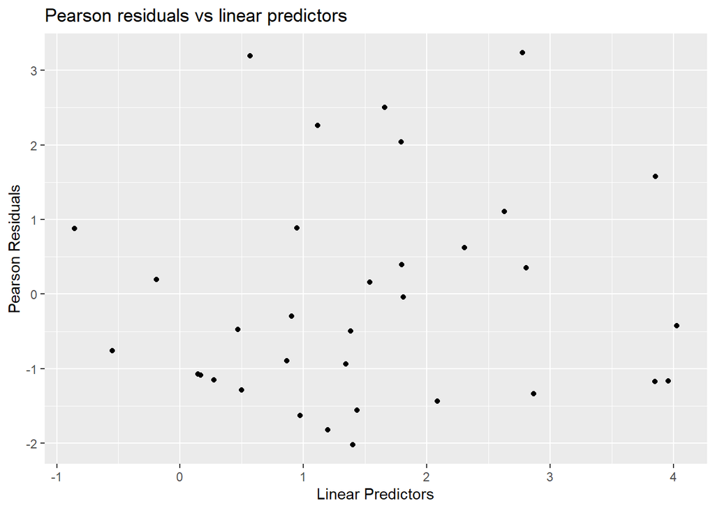

```r
library(ggplot2)

graph_frame <- data.frame(
    pearson_resids = residuals(ship_poisson, type = "pearson"),
      linear_pred = predict(ship_poisson, type = "link"))

ggplot(graph_frame, aes(x = linear_pred, y = pearson_resids)) + geom_point() +
     labs(title= "Pearson residuals vs linear predictors",
                        x = "Linear Predictors",
                        y = "Pearson Residuals")
```

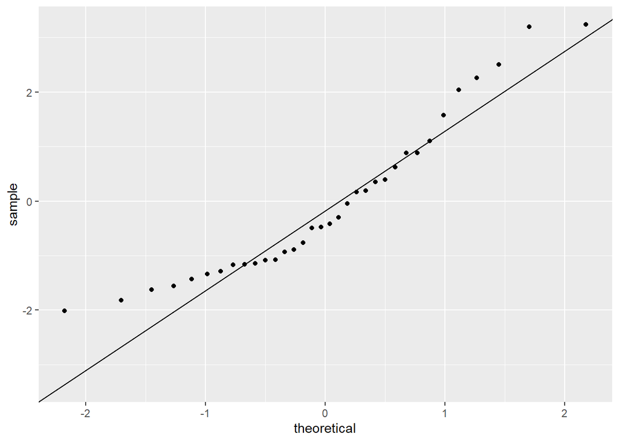

```r
ggplot(graph_frame, aes(sample = pearson_resids)) + geom_qq_line() + geom_qq()
```

The first plot seems to be mostly randomly scattered which is good but the QQ plot has tails which indicates it is not a good fit.

### Part d (5 points)

Conduct a deviance goodness-of-fit (GOF) test for a lack of fit here. Type out the null and alternative hypotheses, report the test statistic, give the p-value, and provide an interpretation.

### Part e (4 points)

Is there evidence that this model has overdispersion? Explain.

### Part f (6 points)

Fit a “quasipoisson” model to these data. Using this model, obtain an approximate 95% confidence interval for the mean response for a ship of type “B” with construction between 1965 and 1969, with operation between 1960 and 1974, and with 2000 aggregate months of service. You can construct this interval using a t critical value with 24 degrees of freedom since the quasipoisson family more closely follows a t distribution than a normal one. Interpret the interval.

### Part g (5 points)

Now construct an approximate 95% prediction interval for the number of incidents for the ship described in part f using the `qpois()` function. Interpret the interval.

### Part h (6 points)

Suppose we did not catch the fact that this model is overdispersed. Repeat parts f and g using the model fit with the “poisson” family, not “quasipoisson” and using a z interval for the mean response rather than a t interval. Compare your results to parts f and g and comment on what is different.